# ESM_body

Matu Silviu-Andrei

2024-12-27

## Load packages

```r
if (!require("pacman")) install.packages("pacman")
```

```r
pacman::p_load(
  plyr, #this has to be before dplyr
  dplyr,
  effectsize,
  emmeans,
  flextable,
  ggplot2,
  haven,
  here,
  kableExtra,
  knitr,
  kableExtra,
  lme4,
  matrixStats,
  mice,
  miceadds,
  nlme,
  RcmdrMisc,
  rmarkdown,
  readr,
  rlang,
  sjPlot,
  sjmisc,
  sjlabelled,
  stringr,
  tibble,
  tidyr,
  tidyverse
)


working_folder_path <- here()
setwd(working_folder_path)
data <- read.csv('Input_data.csv')
options(max.print=9999)
options(width = 500)

version_number=20 #only used to keep track of the versions of the files
```

## Pre-processing

### Replace group column values with 0 and 1

Group 1 becomes group 0, and group 2 becomes group 1.

```r
replace_with_0_1  <- function(data, cols_to_replace){
  for (column in cols_to_replace) {
    data[[column]][data[[column]] == 1] <- 0
    data[[column]][data[[column]] == 2] <- 1
    }
  return (data)
}

cols_to_replace <- c('group')
data<-replace_with_0_1(data, cols_to_replace)
```

### Change time variables so that they start with 0

```r
minus_1 <- function(data, cols_to_change){
  for (column in cols_to_change){
    data[[column]]<-data[[column]]-1
  }
  return(data)
}

cols_to_change<-c('day', 'beep')
data<-minus_1(data, cols_to_change)
```

### One participant does not have exact time recordings for the beeps. They are raplaced with some default values

```r
replacement_time=570

for (beep_no in 0:4){
  #first beep is replaced with 9:30 and all next ones receive times that are 2 hours after the previous one
  data[data$id == 25 & data$beep == beep_no, "beeptime"] <- replacement_time
  replacement_time=replacement_time+120
}
```

### Compute a continous time variable reflecting the times passed since the start of the first day in the study

```r
compute_continous_time <- function(data, higher_framework_time_column, lower_framework_time_column, continuous_time_column, ratio_higher_lower_frameworktime) {
  data[[continuous_time_column]] <- data[[higher_framework_time_column]] * ratio_higher_lower_frameworktime + data[[lower_framework_time_column]]
  return(data)
}

higher_framework_time_column <- 'day'
lower_framework_time_column <- 'beeptime'
continuous_time_column <- 'beeptime_continous'
ratio_higher_lower_frameworktime <- 1440 # 1440 transforms days into minutes

data <- compute_continous_time(data, higher_framework_time_column, lower_framework_time_column, continuous_time_column, ratio_higher_lower_frameworktime)
```

### Compute a variable that can identify the beep in the sequence of all beeps across all days

```r
data$day_beep <- data$day*5+data$beep
```

### Rescale the continous time varaibles

```r
rescale_minutes_to_hours <- function(data, cols_to_rescale){
  for (column in cols_to_rescale) {
    data[[column]]<-data[[column]]/60
  }
  return(data)
}

cols_to_rescale<-c('beeptime','beeptime_continous') #both will be now expressed in hours
data<-rescale_minutes_to_hours(data, cols_to_rescale)
```

### Sort by id, day and beep

```r
sort_multiple_columns <- function(data, cols_for_sorting){
  data <- data %>%
    arrange(across(all_of(cols_for_sorting)))

  return(data)
}

cols_for_sorting<-c('id', 'day', 'beep')
data<-sort_multiple_columns(data, cols_for_sorting)
```

### Setting the names of key columns as separate variables to be called easily in functions

```r
id_variable_name<-'id'
day_variable_name<-'day'
beep_number_variable_name<-'beep'
beep_time_variable_name<-'beeptime'
group_variable_name<-'group'

#bellow is the continuous time variable computed above;
continous_beep_variable_name<-'beeptime_continous'

#bellow is the variable that indicates the beep number across all days
unique_beep_number<-'day_beep'
```

### Compute ciritical event variable

```r
data <- data %>%
  mutate(critical_event = ifelse(NA_3>=3 | BS_1 >= 3 | SE_1 >= 3, 1, 0))

#putting the name of the column inside a variable
critical_event_variable_name<-'critical_event'
```

### Center group and critical event

```r
data <- data %>%
  mutate(
    group_centred = as.numeric(scale(.data[[group_variable_name]], scale = FALSE)),
    critical_event_centred = as.numeric(scale(.data[[critical_event_variable_name]], scale = FALSE))
    )

#again, putting the names of the columns inside dedicated variables
critical_event_centred_variable_name<-'critical_event_centred'
group_centred_variable_name<-'group_centred'
```

### Computing lag for the critical event variable and its centred version

```r
#making sure that the data is sorted
data<-sort_multiple_columns(data, cols_for_sorting)

compute_lag <- function(data, cols_to_process, id_variable_name, day_variable_name) {
  for (variable in cols_to_process) {
    lag_variable_name <- paste0('lag_', variable)
    data <- data %>%
      group_by(.data[[id_variable_name]], .data[[day_variable_name]]) %>%
      mutate(!!lag_variable_name:= lag(.data[[variable]], n = 1, default = NA)) %>%
      ungroup()
  }
  return(data)
}

cols_to_process<-c(critical_event_variable_name, critical_event_centred_variable_name)
data<-compute_lag(data, cols_to_process, id_variable_name, day_variable_name)

lagged_critical_event_variable_name<-'lag_critical_event'
lagged_critical_event_centred_variable_name<-'lag_critical_event_centred'
```

## Descriptives

### Dropping rows for beeps with no report

```r
#the data frame at this points includes empty rows for beeps that did not receive a response
#we will remove those rows for the descriptive analysis
#but we would like to keep the information on those rows namely the participant id and the time when the notification was sent
complete_data<-data #keeping a copy of the original data to be used later

data <- data %>% filter(!is.na(beepresp)) #dropping rows for beeps with no response

#we use 'data' in function calls but the actual content might changes across sections of the analysis
#we keep a copy of the data used for different purposes; here we keep a copy of the data used for the descriptive analysis
data_for_descriptives <- data
```

### No. of participants

```r
unique_count_overall <- length(unique(data$id))
print(paste0('Total N: ', unique_count_overall))
```

```
## [1] "Total N: 93"
```

```r
# saving data for each group in dedicated dataframes
filtered_group_0 <- data[data$group == 0, ]
unique_ids_group_0 <- unique(filtered_group_0$id)
print(paste0('Total N in group 0: ', length(unique_ids_group_0)))
```

```
## [1] "Total N in group 0: 47"
```

```r
filtered_group_1 <- data[data$group == 1, ]
unique_ids_group_1 <- unique(filtered_group_1$id)
print(paste0('Total N in group 1: ', length(unique_ids_group_1)))
```

```
## [1] "Total N in group 1: 46"
```

```r
number_reports <- nrow(data)
print(paste0('Total number of reports: ', number_reports))
```

```
## [1] "Total number of reports: 1534"
```

```r
number_reports_group_0 <- nrow(filtered_group_0)
print(paste0('Total number of reports in group 0: ', number_reports_group_0))
```

```
## [1] "Total number of reports in group 0: 850"
```

```r
number_reports_group_1 <- nrow(filtered_group_1)
print(paste0('Total number of reports in group 1: ', number_reports_group_1))
```

```
## [1] "Total number of reports in group 1: 684"
```

```r
print(unique_ids_group_0)
```

```
##  [1] 47 48 49 50 51 52 53 54 55 56 57 58 59 60 61 62 63 64 65 66 67 68 69 70 71 72 73 74 75 76 77 78 79 80 81 82 83 84 85 86 87 88 89 90 91 92 93
```

```r
print(unique_ids_group_1)
```

```
##  [1]  1  2  3  4  5  6  7  8  9 10 11 12 13 14 15 16 17 18 19 20 21 22 23 24 25 26 27 28 29 30 31 32 33 34 35 36 37 38 39 40 41 42 43 44 45 46
```

```r
study_number_of_beeps=35
study_number_days=7
study_beeps_day=5
total_expected_reports=unique_count_overall*study_number_of_beeps
print(paste0('Total number of expected reports: ', total_expected_reports))
```

```
## [1] "Total number of expected reports: 3255"
```

```r
print(paste0('Percentage of actual reports from the expected total: ', number_reports/total_expected_reports))
```

```
## [1] "Percentage of actual reports from the expected total: 0.471274961597542"
```

### Count number of beeps per participant and per day/participant

```r
count_beeps_participant <- data %>%
  group_by(id) %>%
  summarize(count = n(), .groups = 'drop')
print(paste0('Average number of beeps per participant: ', mean(count_beeps_participant$count), ' Standard deviation:',
             sd(count_beeps_participant$count)))
```

```
## [1] "Average number of beeps per participant: 16.494623655914 Standard deviation:10.3615338548024"
```

```r
print(paste0('Average percentage of responses from the total expected number of beeps (compliance in %): ',
             mean((count_beeps_participant$count/study_number_of_beeps)*100)))
```

```
## [1] "Average percentage of responses from the total expected number of beeps (compliance in %): 47.1274961597542"
```

```r
count_beeps_participant_group_0 <- filtered_group_0 %>%
  group_by(id) %>%
  summarize(count = n(), .groups = 'drop')
print(paste0('Average number of beeps per participant in group 0: ', mean(count_beeps_participant_group_0$count), ' Standard deviation:', sd(count_beeps_participant_group_0$count)))
```

```
## [1] "Average number of beeps per participant in group 0: 18.0851063829787 Standard deviation:9.80201795380408"
```

```r
count_beeps_participant_group_1 <- filtered_group_1 %>%
  group_by(id) %>%
  summarize(count = n(), .groups = 'drop')
print(paste0('Average number of beeps per participant in group 1: ', mean(count_beeps_participant_group_1$count), ' Standard deviation:', sd(count_beeps_participant_group_1$count)))
```

```
## [1] "Average number of beeps per participant in group 1: 14.8695652173913 Standard deviation:10.7674585790338"
```

```r
#per day averages
print(paste0('Average number of responses per day from the total expected number of beeps: ',
             mean(count_beeps_participant$count/study_number_days)))
```

```
## [1] "Average number of responses per day from the total expected number of beeps: 2.35637480798771"
```

```r
print(paste0('Average number of responses per day from the total expected number of beeps in group 0: ',
             mean(count_beeps_participant_group_0$count/study_number_days)))
```

```
## [1] "Average number of responses per day from the total expected number of beeps in group 0: 2.58358662613982"
```

```r
print(paste0('Average number of responses per day from the total expected number of beeps in group 1: ',
             mean(count_beeps_participant_group_1$count/study_number_days)))
```

```
## [1] "Average number of responses per day from the total expected number of beeps in group 1: 2.12422360248447"
```

```r
no_participants_higher_17 <- count_beeps_participant %>%
  filter(count >= 17 ) %>%
  summarize(no_participants = n()) %>%
  pull(no_participants)
print(paste0('Number of participnts that respondend to 17 or more of the beeps: ', no_participants_higher_17))
```

```
## [1] "Number of participnts that respondend to 17 or more of the beeps: 47"
```

```r
print(paste0('Percentage of participnts that respondend to 17 or more of the beeps: ', no_participants_higher_17/unique_count_overall))
```

```
## [1] "Percentage of participnts that respondend to 17 or more of the beeps: 0.505376344086022"
```

```r
print('Number of beeps for each participant:')
```

```
## [1] "Number of beeps for each participant:"
```

```r
print(count_beeps_participant)
```

```
## # A tibble: 93 × 2
##       id count
##    <int> <int>
##  1     1    23
##  2     2    32
##  3     3    32
##  4     4     1
##  5     5     1
##  6     6     1
##  7     7    11
##  8     8     3
##  9     9    13
## 10    10    20
## # ℹ 83 more rows
```

```r
write.csv(count_beeps_participant, file='Number_of_beeps_per_participant.csv', row.names=F)
```

### Count number of beeps per day/participant in the observed days (i.e., average number of beeps in days in which they reported at least a beep)

#### This is less informative; we are more intereted overall, rather than the days in which they reported.

```r
count_beeps_participant_day_observed <- data %>%
  group_by(id, day) %>%
  summarize(count = n(), .groups = 'drop')
print(paste0('Average number of beeps per participant per day in reporting days: ', mean(count_beeps_participant_day_observed$count), ' Standard deviation:', sd(count_beeps_participant_day_observed$count)))
```

```
## [1] "Average number of beeps per participant per day in reporting days: 3.18257261410788 Standard deviation:1.36173853196403"
```

```r
count_beeps_participant_day_observed_group_0 <- filtered_group_0 %>%
  group_by(id, day) %>%
  summarize(count = n(), .groups = 'drop')
print(paste0('Average number of beeps per participant per day in reporting days in group 0: ', mean(count_beeps_participant_day_observed_group_0$count), ' Standard deviation:', sd(count_beeps_participant_day_observed_group_0$count)))
```

```
## [1] "Average number of beeps per participant per day in reporting days in group 0: 3.20754716981132 Standard deviation:1.33369063251528"
```

```r
count_beeps_participant_day_observed_group_1 <- filtered_group_1 %>%
  group_by(id, day) %>%
  summarize(count = n(), .groups = 'drop')
print(paste0('Average number of beeps per participant per day in reporting days in group 1: ', mean(count_beeps_participant_day_observed_group_1$count), ' Standard deviation:', sd(count_beeps_participant_day_observed_group_1$count)))
```

```
## [1] "Average number of beeps per participant per day in reporting days in group 1: 3.15207373271889 Standard deviation:1.39771898638771"
```

### Compute means, SDs and other statistics

```r
descriptives_overall <- function(data, cols_to_compute) {
  descriptives_datasets_list <- list()
  for (variable in cols_to_compute) {
    descriptive_stats_data <- data %>%
      filter(!is.na(.data[[variable]])) %>%
      summarize(
        count = n(),
        mean = round(mean(.data[[variable]], na.rm = TRUE), 2),
        sd = round(sd(.data[[variable]], na.rm = TRUE), 2),
        min = round(min(.data[[variable]], na.rm = TRUE), 2),
        max = round(max(.data[[variable]], na.rm = TRUE), 2),
        median = round(median(.data[[variable]], na.rm = TRUE), 2),
        IQR = round(IQR(.data[[variable]], na.rm = TRUE), 2),
        na_percentage = round(sum(is.na(.data[[variable]]))/n(), 4),
        .groups = 'drop'
      )
    descriptive_stats_data <- descriptive_stats_data %>%
      mutate(variable = variable)
    descriptives_datasets_list[[variable]] <- descriptive_stats_data
  }
  descriptives_combined <- bind_rows(descriptives_datasets_list)
  return(descriptives_combined)
}

descriptives_by_group <- function(data, cols_to_compute, group_column_name) {
  descriptives_datasets_list <- list()
  for (variable in cols_to_compute) {
    descriptive_stats_data <- data %>%
      filter(!is.na(.data[[variable]])) %>%
      group_by(.data[[group_column_name]]) %>%
      summarize(
        count = n(),
        mean = round(mean(.data[[variable]], na.rm = TRUE), 2),
        sd = round(sd(.data[[variable]], na.rm = TRUE), 2),
        min = round(min(.data[[variable]], na.rm = TRUE), 2),
        max = round(max(.data[[variable]], na.rm = TRUE), 2),
        median = round(median(.data[[variable]], na.rm = TRUE), 2),
        IQR = round(IQR(.data[[variable]], na.rm = TRUE), 2),
        na_percentage = round(sum(is.na(.data[[variable]]))/n(), 4),
        .groups = 'drop'
      )
    descriptive_stats_data <- descriptive_stats_data %>%
      mutate(variable = variable)
    descriptives_datasets_list[[variable]] <- descriptive_stats_data
  }
  descriptives_combined <- bind_rows(descriptives_datasets_list)
  return(descriptives_combined)
}

create_apa_table <- function(descriptive_stats) {
  ft <- flextable(descriptive_stats)
  ft <- set_header_labels(ft,
                          variable = "Variable",
                          count = "N",
                          mean = "Mean",
                          sd = "SD",
                          min = "Min",
                          max = "Max",
                          median = "Median",
                          IQR = "IQR",
                          na_percentage = "% missing")
  ft <- autofit(ft)
  ft <- theme_vanilla(ft)
  return(ft)
}

create_apa_table_by_group <- function(descriptive_stats) {
  ft <- flextable(descriptive_stats)
  ft <- set_header_labels(ft,
                          group = "Group",
                          variable = "Variable",
                          count = "N",
                          mean = "Mean",
                          sd = "SD",
                          min = "Min",
                          max = "Max",
                          median = "Median",
                          IQR = "IQR",
                          na_percentage = "% missing")
  ft <- autofit(ft)
  ft <- theme_vanilla(ft)
  return(ft)
}

#Variables used for descriptives
cols_to_compute<-c('age',
                   'beepresp',
                   'beepdurat',
                   'Body_check',
                   'Restr',
                   'Comp',
                   'BE',
                   'EE',
                   'NA_1',
                   'NA_2',
                   'NA_3',
                   'NA_4',
                   'NA_5',
                   'NA_6',
                   'BS_1',
                   'BS_2',
                   'SE_1',
                   'SE_2',
                   'SS')

group_column_name<-'group'

descriptives_overall_results<-descriptives_overall(data, cols_to_compute)
descriptives_apa_table_overall<- create_apa_table(descriptives_overall_results)
descriptives_apa_table_overall
```

| N | Mean | SD | Min | Max | Median | IQR | % missing | Variable |
| --- | --- | --- | --- | --- | --- | --- | --- | --- |
| 1,534 | 27.17 | 7.61 | 18.00 | 51.00 | 25.00 | 11.00 | 0 | age |
| 1,534 | 929.57 | 249.06 | 510.00 | 1,463.00 | 930.50 | 438.00 | 0 | beepresp |
| 1,520 | 142.44 | 566.29 | 26.52 | 17,143.72 | 75.93 | 65.08 | 0 | beepdurat |
| 1,534 | 2.82 | 1.44 | 1.00 | 5.00 | 3.00 | 2.00 | 0 | Body_check |
| 1,534 | 2.48 | 1.48 | 1.00 | 5.00 | 2.00 | 3.00 | 0 | Restr |
| 1,534 | 1.16 | 0.62 | 1.00 | 5.00 | 1.00 | 0.00 | 0 | Comp |
| 1,534 | 1.95 | 1.27 | 1.00 | 5.00 | 1.00 | 2.00 | 0 | BE |
| 1,534 | 1.29 | 0.74 | 1.00 | 5.00 | 1.00 | 0.00 | 0 | EE |
| 1,534 | 1.72 | 1.05 | 1.00 | 5.00 | 1.00 | 1.00 | 0 | NA_1 |
| 1,534 | 2.46 | 1.32 | 1.00 | 5.00 | 2.00 | 2.00 | 0 | NA_2 |
| 1,534 | 1.99 | 1.23 | 1.00 | 5.00 | 2.00 | 2.00 | 0 | NA_3 |
| 1,534 | 2.11 | 1.29 | 1.00 | 5.00 | 2.00 | 2.00 | 0 | NA_4 |
| 1,534 | 1.55 | 0.98 | 1.00 | 5.00 | 1.00 | 1.00 | 0 | NA_5 |
| 1,534 | 2.07 | 1.25 | 1.00 | 5.00 | 2.00 | 2.00 | 0 | NA_6 |
| 1,534 | 3.15 | 1.35 | 1.00 | 5.00 | 3.00 | 2.00 | 0 | BS_1 |
| 1,534 | 2.82 | 1.36 | 1.00 | 5.00 | 3.00 | 2.00 | 0 | BS_2 |
| 1,534 | 3.21 | 1.36 | 1.00 | 5.00 | 3.00 | 2.00 | 0 | SE_1 |
| 1,534 | 3.05 | 1.41 | 1.00 | 5.00 | 3.00 | 2.00 | 0 | SE_2 |
| 1,534 | 2.83 | 1.36 | 1.00 | 5.00 | 3.00 | 2.00 | 0 | SS |

```r
descriptives_by_group_combined <- descriptives_by_group(data, cols_to_compute, group_column_name)
descriptives_apa_table_by_group<- create_apa_table_by_group(descriptives_by_group_combined)
print(descriptives_apa_table_by_group)
```

```
## a flextable object.
## col_keys: `group`, `count`, `mean`, `sd`, `min`, `max`, `median`, `IQR`, `na_percentage`, `variable`
## header has 1 row(s)
## body has 38 row(s)
## original dataset sample:
##   group count   mean     sd    min      max median    IQR na_percentage  variable
## 1     0   850  25.20   6.05  19.00    51.00  24.00   6.00             0       age
## 2     1   684  29.61   8.58  18.00    50.00  28.00  15.00             0       age
## 3     0   850 931.36 246.53 512.00  1348.00 931.50 434.00             0  beepresp
## 4     1   684 927.33 252.33 510.00  1463.00 928.00 444.00             0  beepresp
## 5     0   839 108.70 606.65  26.52 17143.72  65.69  32.53             0 beepdurat
```

### Counting number of critical events

```r
number_of_total_critical_events <- data %>%
  filter(critical_event == 1 ) %>%
  summarize(count = n()) %>%
  pull(count)
print(paste0('Total number of reports with critical events (any type; multiple types in the same report are counted only once): ', number_of_total_critical_events))
```

```
## [1] "Total number of reports with critical events (any type; multiple types in the same report are counted only once): 1168"
```

```r
number_of_total_critical_events_NA <- data %>%
  filter(NA_3 >= 3 ) %>%
  summarize(count = n()) %>%
  pull(count)
print(paste0('Total number of reports with critical events (general shame): ', number_of_total_critical_events_NA))
```

```
## [1] "Total number of reports with critical events (general shame): 427"
```

```r
number_of_total_critical_events_BS <- data %>%
  filter(BS_1 >= 3 ) %>%
  summarize(count = n()) %>%
  pull(count)
print(paste0('Total number of reports with critical events (body shame): ', number_of_total_critical_events_BS))
```

```
## [1] "Total number of reports with critical events (body shame): 977"
```

```r
number_of_total_critical_events_SE <- data %>%
  filter(SE_1 >= 3 ) %>%
  summarize(count = n()) %>%
  pull(count)
print(paste0('Total number of reports with critical events (shame about eating): ', number_of_total_critical_events_SE))
```

```
## [1] "Total number of reports with critical events (shame about eating): 1030"
```

```r
number_of_total_critical_events_group_0 <- filtered_group_0 %>%
  filter(critical_event == 1 ) %>%
  summarize(count = n()) %>%
  pull(count)
print(paste0('Total number of reports with critical events (any type; multiple types in the same report are counted only once) in group 0: ', number_of_total_critical_events_group_0))
```

```
## [1] "Total number of reports with critical events (any type; multiple types in the same report are counted only once) in group 0: 740"
```

```r
number_of_total_critical_events_NA_group_0 <- filtered_group_0 %>%
  filter(NA_3 >= 3 ) %>%
  summarize(count = n()) %>%
  pull(count)
print(paste0('Total number of reports with critical events (general shame) in group 0: ', number_of_total_critical_events_NA_group_0))
```

```
## [1] "Total number of reports with critical events (general shame) in group 0: 299"
```

```r
number_of_total_critical_events_BS_group_0 <- filtered_group_0 %>%
  filter(BS_1 >= 3 ) %>%
  summarize(count = n()) %>%
  pull(count)
print(paste0('Total number of reports with critical events (body shame) in group 0: ', number_of_total_critical_events_BS_group_0))
```

```
## [1] "Total number of reports with critical events (body shame) in group 0: 677"
```

```r
number_of_total_critical_events_SE_group_0 <- filtered_group_0 %>%
  filter(SE_1 >= 3 ) %>%
  summarize(count = n()) %>%
  pull(count)
print(paste0('Total number of reports with critical events (shame about eating) in group 0: ', number_of_total_critical_events_SE_group_0))
```

```
## [1] "Total number of reports with critical events (shame about eating) in group 0: 656"
```

```r
number_of_total_critical_events_group_1 <- filtered_group_1 %>%
  filter(critical_event == 1 ) %>%
  summarize(count = n()) %>%
  pull(count)
print(paste0('Total number of reports with critical events (any type; multiple types in the same report are counted only once) in group 1: ', number_of_total_critical_events_group_1))
```

```
## [1] "Total number of reports with critical events (any type; multiple types in the same report are counted only once) in group 1: 428"
```

```r
number_of_total_critical_events_NA_group_1 <- filtered_group_1 %>%
  filter(NA_3 >= 3 ) %>%
  summarize(count = n()) %>%
  pull(count)
print(paste0('Total number of reports with critical events (general shame) in group 1: ', number_of_total_critical_events_NA_group_1))
```

```
## [1] "Total number of reports with critical events (general shame) in group 1: 128"
```

```r
number_of_total_critical_events_BS_group_1 <- filtered_group_1 %>%
  filter(BS_1 >= 3 ) %>%
  summarize(count = n()) %>%
  pull(count)
print(paste0('Total number of reports with critical events (body shame) in group 1: ', number_of_total_critical_events_BS_group_1))
```

```
## [1] "Total number of reports with critical events (body shame) in group 1: 300"
```

```r
number_of_total_critical_events_SE_group_1 <- filtered_group_1 %>%
  filter(SE_1 >= 3 ) %>%
  summarize(count = n()) %>%
  pull(count)
print(paste0('Total number of reports with critical events (shame about eating) in group 1: ', number_of_total_critical_events_SE_group_1))
```

```
## [1] "Total number of reports with critical events (shame about eating) in group 1: 374"
```

```r
#bellow we also have to count participants with 0s
number_of_critical_events_per_participant <- data %>%
  group_by(id) %>%
  summarize(count = sum(critical_event == 1, na.rm = TRUE)) %>%
  ungroup()
print(paste0('Mean number of reports with critical events (any type; multiple types in the same report are counted only once): ',
             mean(number_of_critical_events_per_participant$count), ', and SD: ', sd(number_of_critical_events_per_participant$count)))
```

```
## [1] "Mean number of reports with critical events (any type; multiple types in the same report are counted only once): 12.5591397849462, and SD: 9.87471778968391"
```

```r
number_of_critical_events_per_participant_NA <- data %>%
  group_by(id) %>%
  summarize(count = sum(NA_3 >= 3, na.rm = TRUE)) %>%
  ungroup()
print(paste0('Mean number of reports with critical events (NA): ',
             mean(number_of_critical_events_per_participant_NA$count), ', and SD: ', sd(number_of_critical_events_per_participant_NA$count)))
```

```
## [1] "Mean number of reports with critical events (NA): 4.59139784946237, and SD: 5.88704650083884"
```

```r
number_of_critical_events_per_participant_BS <- data %>%
  group_by(id) %>%
  summarize(count = sum(BS_1 >= 3, na.rm = TRUE)) %>%
  ungroup()
print(paste0('Mean number of reports with critical events (BS): ',
             mean(number_of_critical_events_per_participant_BS$count), ', and SD: ', sd(number_of_critical_events_per_participant_BS$count)))
```

```
## [1] "Mean number of reports with critical events (BS): 10.505376344086, and SD: 9.42893748441925"
```

```r
number_of_critical_events_per_participant_SE <- data %>%
  group_by(id) %>%
  summarize(count = sum(SE_1 >= 3, na.rm = TRUE)) %>%
  ungroup()
print(paste0('Mean number of reports with critical events (SE): ',
             mean(number_of_critical_events_per_participant_SE$count), ', and SD: ', sd(number_of_critical_events_per_participant_SE$count)))
```

```
## [1] "Mean number of reports with critical events (SE): 11.0752688172043, and SD: 9.75820341529849"
```

```r
number_of_critical_events_per_participant_group_0 <- filtered_group_0 %>%
  group_by(id) %>%
  summarize(count = sum(critical_event == 1, na.rm = TRUE)) %>%
  ungroup()
print(paste0('Mean number of reports with critical events (any type; multiple types in the same report are counted only once) in group 0: ',
             mean(number_of_critical_events_per_participant_group_0$count), ', and SD: ', sd(number_of_critical_events_per_participant_group_0$count)))
```

```
## [1] "Mean number of reports with critical events (any type; multiple types in the same report are counted only once) in group 0: 15.7446808510638, and SD: 10.07896665922"
```

```r
number_of_critical_events_per_participant_NA_group_0 <- filtered_group_0 %>%
  group_by(id) %>%
  summarize(count = sum(NA_3 >= 3, na.rm = TRUE)) %>%
  ungroup()
print(paste0('Mean number of reports with critical events (NA) for group 0: ',
             mean(number_of_critical_events_per_participant_NA_group_0$count), ', and SD: ', sd(number_of_critical_events_per_participant_NA_group_0$count)))
```

```
## [1] "Mean number of reports with critical events (NA) for group 0: 6.36170212765957, and SD: 6.30536532029562"
```

```r
number_of_critical_events_per_participant_BS_group_0 <- filtered_group_0 %>%
  group_by(id) %>%
  summarize(count = sum(BS_1 >= 3, na.rm = TRUE)) %>%
  ungroup()
print(paste0('Mean number of reports with critical events (BS) for group 0: ',
             mean(number_of_critical_events_per_participant_BS_group_0$count), ', and SD: ', sd(number_of_critical_events_per_participant_BS_group_0$count)))
```

```
## [1] "Mean number of reports with critical events (BS) for group 0: 14.4042553191489, and SD: 9.60448168591799"
```

```r
number_of_critical_events_per_participant_SE_group_0 <- filtered_group_0 %>%
  group_by(id) %>%
  summarize(count = sum(SE_1 >= 3, na.rm = TRUE)) %>%
  ungroup()
print(paste0('Mean number of reports with critical events (SE) for group 0: ',
             mean(number_of_critical_events_per_participant_SE_group_0$count), ', and SD: ', sd(number_of_critical_events_per_participant_SE_group_0$count)))
```

```
## [1] "Mean number of reports with critical events (SE) for group 0: 13.9574468085106, and SD: 9.91914584069947"
```

```r
number_of_critical_events_per_participant_group_1 <- filtered_group_1 %>%
  group_by(id) %>%
  summarize(count = sum(critical_event == 1, na.rm = TRUE)) %>%
  ungroup()
print(paste0('Mean number of reports with critical events (any type; multiple types in the same report are counted only once) in group 1: ',
             mean(number_of_critical_events_per_participant_group_1$count), ', and SD: ', sd(number_of_critical_events_per_participant_group_1$count)))
```

```
## [1] "Mean number of reports with critical events (any type; multiple types in the same report are counted only once) in group 1: 9.30434782608696, and SD: 8.60715352410073"
```

```r
number_of_critical_events_per_participant_NA_group_1 <- filtered_group_1 %>%
  group_by(id) %>%
  summarize(count = sum(NA_3 >= 3, na.rm = TRUE)) %>%
  ungroup()
print(paste0('Mean number of reports with critical events (NA) for group 1: ',
             mean(number_of_critical_events_per_participant_NA_group_1$count), ', and SD: ', sd(number_of_critical_events_per_participant_NA_group_1$count)))
```

```
## [1] "Mean number of reports with critical events (NA) for group 1: 2.78260869565217, and SD: 4.85758533282746"
```

```r
number_of_critical_events_per_participant_BS_group_1 <- filtered_group_1 %>%
  group_by(id) %>%
  summarize(count = sum(BS_1 >= 3, na.rm = TRUE)) %>%
  ungroup()
print(paste0('Mean number of reports with critical events (BS) for group 1: ',
             mean(number_of_critical_events_per_participant_BS_group_1$count), ', and SD: ', sd(number_of_critical_events_per_participant_BS_group_1$count)))
```

```
## [1] "Mean number of reports with critical events (BS) for group 1: 6.52173913043478, and SD: 7.44084562229853"
```

```r
number_of_critical_events_per_participant_SE_group_1 <- filtered_group_1 %>%
  group_by(id) %>%
  summarize(count = sum(SE_1 >= 3, na.rm = TRUE)) %>%
  ungroup()
print(paste0('Mean number of reports with critical events (SE) for group 1: ',
             mean(number_of_critical_events_per_participant_SE_group_1$count), ' and SD: ', sd(number_of_critical_events_per_participant_SE_group_1$count)))
```

```
## [1] "Mean number of reports with critical events (SE) for group 1: 8.1304347826087 and SD: 8.74987922621964"
```

```r
print('Number of critical events per participant:')
```

```
## [1] "Number of critical events per participant:"
```

```r
print(number_of_critical_events_per_participant)
```

```
## # A tibble: 93 × 2
##       id count
##    <int> <int>
##  1     1     4
##  2     2     6
##  3     3     2
##  4     4     1
##  5     5     1
##  6     6     1
##  7     7     2
##  8     8     3
##  9     9     2
## 10    10     2
## # ℹ 83 more rows
```

```r
write.csv(number_of_critical_events_per_participant, file='Number_of_critical_events_per_participant.csv', row.names=F)

print(paste0('Percentage of of reports with critial events across both groups: ', number_of_total_critical_events/number_reports))
```

```
## [1] "Percentage of of reports with critial events across both groups: 0.761408083441982"
```

```r
print(paste0('Percentage of of reports with critial events in group 0: ', number_of_total_critical_events_group_0/number_reports_group_0))
```

```
## [1] "Percentage of of reports with critial events in group 0: 0.870588235294118"
```

```r
print(paste0('Percentage of of reports with critial events in group 1: ', number_of_total_critical_events_group_1/number_reports_group_1))
```

```
## [1] "Percentage of of reports with critial events in group 1: 0.625730994152047"
```

## Analysis

### Dependent variables to work with

```r
cols_to_analyze<-c('Body_check',
                   'Restr',
                   'Comp',
                   'BE',
                   'EE'
                   )

cols_for_plots<-c('Body Check',
                 'Dietary Restraint',
                 'Compensatory Behaviours',
                 'Binge Eating',
                 'Excesive Exercise'
                 )
```

### Multilevel models

```r
lme_analysis <- function(dataset, cols_to_analyze, id_variable_name, day_variable_name, beep_time_variable_name, group_variable_name, critical_event_variable_name, control_params, variable_name_defining_correlation_structure, estimation, factors=FALSE) {

  df<-dataset

  if (factors) {
    df[[group_variable_name]] <- as.factor(df[[group_variable_name]])
    df[[critical_event_variable_name]] <- as.factor(df[[critical_event_variable_name]])
  }

  models_complete <- list()
  models_simple <- list()

  for (variable in cols_to_analyze) {

    formula_fixed_effects <- as.formula(paste0(variable, "~ ", day_variable_name, "+ ",  beep_time_variable_name, "+ ", group_variable_name, "+ ",
                                          critical_event_variable_name, "+ ", critical_event_variable_name, "* ", group_variable_name))

    model_complete <- lme(formula_fixed_effects,
                          random = as.formula(paste0("~1+ ", day_variable_name, "+ ",  beep_time_variable_name, "+ ",
                                                          critical_event_variable_name, "| ", id_variable_name)),
                          na.action = na.omit, #missing data is due to lags;
                          #no prediction is made with NA on the lag variable so no prediction is made from one day to the next
                          correlation = corCAR1(form = as.formula(paste0("~",  variable_name_defining_correlation_structure, "|",
                                                                         id_variable_name, "/",day_variable_name))),
                          data = df, method = estimation,
                          control = control_params)

    models_complete[[variable]] <- model_complete

    model_simple <- lme(formula_fixed_effects,
                        random = as.formula(paste0("~1|", id_variable_name)),
                        na.action = na.omit, #again, missing data comes from lags and is omitted
                        correlation = corCAR1(form = as.formula(paste0("~", variable_name_defining_correlation_structure,"|",
                                                                       id_variable_name, "/", day_variable_name))),
                        data = df, method = estimation,
                        control = control_params)
    models_simple[[variable]] <- model_simple
  }
  return(list(models_complete = models_complete, models_simple = models_simple))
}

#need to be specified for when calling the function
variable_name_defining_correlation_structure='beeptime' #this is also a fixed effects and a random effects variable
estimation='REML'
factors=FALSE


control_params <- lmeControl(maxIter = 100, msMaxIter = 100, tolerance = 1e-6, niterEM = 50, opt = "optim")

REML_models_results <- lme_analysis(data, cols_to_analyze, id_variable_name, day_variable_name, beep_time_variable_name, group_centred_variable_name,
                               lagged_critical_event_centred_variable_name,control_params, variable_name_defining_correlation_structure,
                               estimation, factors)
REML_models_results_complete <- REML_models_results$models_complete
REML_models_results_simple <- REML_models_results$models_simple

ss_col<-c('SS')
REML_models_results_SS <- lme_analysis(data, ss_col, id_variable_name, day_variable_name, beep_time_variable_name, group_centred_variable_name,
                                  critical_event_centred_variable_name, control_params, variable_name_defining_correlation_structure,
                                  estimation, factors)
REML_models_results_complete_SS <- REML_models_results_SS$models_complete
REML_models_results_simple_SS <- REML_models_results_SS$models_simple
```

### Extracting BICs to compare simple with complex models

```r
extract_bic <- function(cols_to_analyze, simple_models, complete_models) {
  bic_results <- list()
  selected_models <- list()  # Initialize the list inside the function

  for (variable in cols_to_analyze) {
    bic_simple <- NA
    bic_complex <- NA


    if (!is.null(simple_models[[variable]])) {
      bic_simple <- BIC(simple_models[[variable]])
    } else {
      message(paste0("Simple model is NULL for: ", variable))
    }

    if (!is.null(complete_models[[variable]])) {
      bic_complex <- BIC(complete_models[[variable]])
    } else {
      message(paste0("Complex model is NULL for: ", variable))
    }

    bic_results[[variable]] <- list(simple = bic_simple, complex = bic_complex)

    if (!is.na(bic_simple) && !is.na(bic_complex)) {
      if (bic_simple > bic_complex) {
        selected_models[[variable]] <- 'complete'
      } else {
        selected_models[[variable]] <- 'simple'
      }
    } else {
      message(paste0("Model comparison cannot be performed for variable: ", variable))
      selected_models[[variable]] <- NULL
    }
  }

  return(list(bic_results = bic_results, selected_models = selected_models))
}

bic_comparison <- extract_bic(cols_to_analyze, REML_models_results_simple, REML_models_results_complete)
bic_values <- bic_comparison$bic_results
selected_models <- bic_comparison$selected_models

print(bic_values)
```

```
## $Body_check
## $Body_check$simple
## [1] 2662.208
##
## $Body_check$complex
## [1] 2722.009
##
##
## $Restr
## $Restr$simple
## [1] 2870.953
##
## $Restr$complex
## [1] 2879.846
##
##
## $Comp
## $Comp$simple
## [1] 1212.862
##
## $Comp$complex
## [1] 1169.306
##
##
## $BE
## $BE$simple
## [1] 2773.941
##
## $BE$complex
## [1] 2795.792
##
##
## $EE
## $EE$simple
## [1] 1820.504
##
## $EE$complex
## [1] 1836.9
```

```r
bic_comparison_SS <- extract_bic(ss_col, REML_models_results_simple_SS, REML_models_results_complete_SS)
bic_value_SS <- bic_comparison_SS$bic_results
selected_models_SS <- bic_comparison_SS$selected_models

print(bic_value_SS)
```

```
## $SS
## $SS$simple
## [1] 4487.836
##
## $SS$complex
## [1] 4473.377
```

### Computing again models with ML estimation and extracting those that were best in the REML estimation using BIC as criterion

```r
estimation='ML' #using ML estimation becasue we are primarly interested in the fixed effects

ML_models_results <- lme_analysis(data, cols_to_analyze, id_variable_name, day_variable_name, beep_time_variable_name, group_centred_variable_name,
                               lagged_critical_event_centred_variable_name,control_params, variable_name_defining_correlation_structure,
                               estimation, factors)
ML_models_results_complete <- ML_models_results$models_complete
ML_models_results_simple <- ML_models_results$models_simple

ML_models_results_SS <- lme_analysis(data, ss_col, id_variable_name, day_variable_name, beep_time_variable_name, group_centred_variable_name,
                                  critical_event_centred_variable_name, control_params, variable_name_defining_correlation_structure,
                                  estimation, factors)
ML_models_results_complete_SS <- ML_models_results_SS$models_complete
ML_models_results_simple_SS <- ML_models_results_SS$models_simple




build_list_final_models<- function(variables_list, selected_models, complete_models, simple_models){
  final_models<-list()

  for (variable in variables_list) {
    if (selected_models[[variable]]=='complete'){
        final_models[[variable]]<-complete_models[[variable]]
    } else if (selected_models[[variable]]=='simple') {
        final_models[[variable]]<-simple_models[[variable]]
    } else {
       final_models[[variable]]<-NULL
    }
  }
  return(final_models)
}

final_models<-build_list_final_models(cols_to_analyze, selected_models, ML_models_results_complete, ML_models_results_simple)
final_models_SS<-build_list_final_models(ss_col, selected_models_SS, ML_models_results_complete_SS, ML_models_results_simple_SS)
merged_final_models <- c(final_models, final_models_SS)
#print(merged_final_models)
```

### Output results for the final models and generate tables

```r
save_tTable_apa <- function(t_table, file_path, variable) {
  t_table_formatted <- as.data.frame(t_table)
  colnames(t_table_formatted) <- c("Estimate", "Std.Error", "df", "t-value", "p-value")

  t_table_formatted <- t_table_formatted %>%
    mutate(across(everything(), ~ round(., 3)))

  kable(t_table_formatted, format = "html", digits = 3, align = "c", caption = paste0("Fixed Effects Table for " , variable))  %>%
    kable_styling("striped", full_width = FALSE, position = "center") %>%
    save_kable(file_path)
}

save_model_summary <- function(model, file_path) {
  sink(file_path)
  cat("<html><body><pre>")
  print(summary(model))
  cat("</pre></body></html>")
  sink()
}


generate_table_models <- function(models, cols_to_analyze, model_type) {
  tables <- list()
  for (variable in cols_to_analyze) {
    print(paste0("Results for: ", variable))
    print(summary(models[[variable]]))
    file_path_tTable <- paste0("Fixed_effects_table_", variable, "_model_v",version_number,"_", model_type,".html")
    file_path_model_summary <- paste0("Model_summary_",variable, "_model_v",version_number,"_", model_type,".html")
    t_table<-as.data.frame(summary(models[[variable]])$tTable)
    save_tTable_apa(t_table, file_path_tTable, variable)
    save_model_summary(models[[variable]], file_path_model_summary)
    tables[[variable]] <- t_table


  }
  return(tables)
}

all_cols_to_analyze<-c(cols_to_analyze, ss_col)

#print('Complete models:')
#complete_models_text<-'complete'
#generate_table_models(ML_models_results_complete, cols_to_analyze, complete_models_text)
#generate_table_models(ML_models_results_complete_SS, ss_col, complete_models_text)


#print('Simple models:')
#simple_models_text<-'simple'
#generate_table_models(ML_models_results_simple, cols_to_analyze, simple_models_text)
#generate_table_models(ML_models_results_simple_SS, ss_col, simple_models_text)

print('Final models:')
```

```
## [1] "Final models:"
```

```r
final_models_text<-'final'
generate_table_models(merged_final_models, all_cols_to_analyze, final_models_text)
```

```
## [1] "Results for: Body_check"
## Linear mixed-effects model fit by maximum likelihood
##   Data: df
##        AIC      BIC    logLik
##   2598.935 2641.769 -1290.468
##
## Random effects:
##  Formula: ~1 | id
##         (Intercept) Residual
## StdDev:   0.8814157 1.001752
##
## Correlation Structure: Continuous AR(1)
##  Formula: ~beeptime | id/day
##  Parameter estimate(s):
##      Phi
## 0.487834
## Fixed effects:  list(formula_fixed_effects)
##                                               Value  Std.Error  DF   t-value p-value
## (Intercept)                               2.6573563 0.20908508 778 12.709450  0.0000
## day                                      -0.0240398 0.01999393 778 -1.202357  0.2296
## beeptime                                  0.0059347 0.01020851 778  0.581345  0.5612
## group_centred                            -0.5262149 0.22226381  78 -2.367524  0.0204
## lag_critical_event_centred                0.3363399 0.12313111 778  2.731559  0.0064
## group_centred:lag_critical_event_centred -0.7837968 0.24596390 778 -3.186634  0.0015
##  Correlation:
##                                          (Intr) day    beeptm grp_cn lg_c__
## day                                      -0.266
## beeptime                                 -0.815  0.040
## group_centred                             0.040  0.009  0.000
## lag_critical_event_centred                0.021  0.007 -0.050  0.111
## group_centred:lag_critical_event_centred  0.021  0.078  0.025 -0.030 -0.302
##
## Standardized Within-Group Residuals:
##         Min          Q1         Med          Q3         Max
## -3.34170531 -0.55773576  0.08015428  0.56058724  3.18913042
##
## Number of Observations: 862
## Number of Groups: 80
## [1] "Results for: Restr"
## Linear mixed-effects model fit by maximum likelihood
```

[output cut: 183 more lines]

```
## group_centred:critical_event_centred -0.3395800 0.28917780 1437 -1.174295  0.2405
##  Correlation:
##                                      (Intr) day    beeptm grp_cn crtc__
## day                                  -0.231
## beeptime                             -0.731  0.068
## group_centred                         0.008  0.000  0.002
## critical_event_centred                0.010  0.074 -0.118  0.061
## group_centred:critical_event_centred  0.021  0.026  0.021 -0.092 -0.160
##
## Standardized Within-Group Residuals:
##         Min          Q1         Med          Q3         Max
## -3.76585982 -0.47075480  0.01966587  0.55949799  3.84796982
##
## Number of Observations: 1534
## Number of Groups: 93
```

```
## $Body_check
##                                                 Value  Std.Error  DF    t-value      p-value
## (Intercept)                               2.657356259 0.20908508 778 12.7094495 9.221426e-34
## day                                      -0.024039840 0.01999393 778 -1.2023570 2.295911e-01
## beeptime                                  0.005934663 0.01020851 778  0.5813448 5.611765e-01
## group_centred                            -0.526214917 0.22226381  78 -2.3675241 2.038588e-02
## lag_critical_event_centred                0.336339896 0.12313111 778  2.7315590 6.446357e-03
## group_centred:lag_critical_event_centred -0.783796817 0.24596390 778 -3.1866336 1.496874e-03
##
## $Restr
##                                                 Value  Std.Error  DF    t-value      p-value
## (Intercept)                               2.593570969 0.23475733 778 11.0478804 1.849123e-26
## day                                      -0.021731681 0.02427288 778 -0.8953069 3.709000e-01
## beeptime                                 -0.007521655 0.01197406 778 -0.6281623 5.300820e-01
## group_centred                            -0.028983587 0.21491047  78 -0.1348635 8.930672e-01
## lag_critical_event_centred                0.139496719 0.13800460 778  1.0108121 3.124206e-01
## group_centred:lag_critical_event_centred  0.246517952 0.27574045 778  0.8940217 3.715867e-01
##
## $Comp
##                                                 Value   Std.Error  DF    t-value      p-value
## (Intercept)                               0.994513431 0.065829505 778 15.1074117 2.078586e-45
## day                                       0.003144861 0.018084374 778  0.1738994 8.619898e-01
## beeptime                                  0.011053486 0.005106983 778  2.1643867 3.073823e-02
## group_centred                            -0.106480154 0.083872408  78 -1.2695493 2.080200e-01
## lag_critical_event_centred               -0.016881658 0.063787148 778 -0.2646561 7.913445e-01
## group_centred:lag_critical_event_centred -0.038792820 0.101449604 778 -0.3823851 7.022802e-01
##
## $BE
##                                                Value  Std.Error  DF    t-value      p-value
## (Intercept)                               1.27048206 0.21162130 778  6.0035643 2.959588e-09
## day                                      -0.05853384 0.02175900 778 -2.6900977 7.296240e-03
## beeptime                                  0.05090488 0.01123884 778  4.5293712 6.843824e-06
## group_centred                            -0.12091528 0.16111225  78 -0.7505033 4.552097e-01
## lag_critical_event_centred                0.33263348 0.12625786 778  2.6345567 8.592262e-03
## group_centred:lag_critical_event_centred -0.65733231 0.25252589 778 -2.6030294 9.416397e-03
##
## $EE
##                                               Value   Std.Error  DF   t-value      p-value
## (Intercept)                              0.95575874 0.126674592 778 7.5449916 1.264704e-13
## day                                      0.01706629 0.013881346 778 1.2294408 2.192783e-01
## beeptime                                 0.01869445 0.006673122 778 2.8014544 5.213607e-03
## group_centred                            0.11622341 0.097407979  78 1.1931610 2.364230e-01
## lag_critical_event_centred               0.02941363 0.072911715 778 0.4034143 6.867543e-01
## group_centred:lag_critical_event_centred 0.05680543 0.145750763 778 0.3897436 6.968328e-01
##
## $SS
##                                             Value   Std.Error   DF    t-value      p-value
## (Intercept)                           2.823464544 0.145823205 1437 19.3622445 2.127873e-74
## day                                   0.007855367 0.023619553 1437  0.3325790 7.395006e-01
## beeptime                             -0.006842900 0.007282488 1437 -0.9396376 3.475614e-01
## group_centred                         0.093469517 0.191884885   91  0.4871125 6.273500e-01
## critical_event_centred                0.104162384 0.146268023 1437  0.7121337 4.764976e-01
## group_centred:critical_event_centred -0.339580001 0.289177803 1437 -1.1742948 2.404715e-01
```

### Function to extract the estimated marginal means (EMMs) for the interaction effects from a givel list of variables and models

```r
get_interaction_emms_from_models <- function(models_list, variable_names, group_variable_name, other_variable_name) {
  emms_list <- list()

  for (variable in variable_names){
    interaction_formula <- as.formula(paste0("~ ",  other_variable_name, "* ", group_variable_name))

    model <- models_list[[variable]]

    emms <- emmeans(model, interaction_formula)
    emms_list[[variable]] <- emms
  }

  return(emms_list)
}
```

### Run models again with non-centred variables and extract EMMs for plotting

```r
factors=FALSE #this could also be set to TRUE and it should not make a difference given that group and critical event are both binary
models_results_for_EMMs <- lme_analysis(data, cols_to_analyze, id_variable_name, day_variable_name, beep_time_variable_name, group_variable_name,
                                        lagged_critical_event_variable_name, control_params, variable_name_defining_correlation_structure,
                                        estimation, factors)
models_results_complete_for_EMMs <- models_results_for_EMMs$models_complete
models_results_simple_for_EMMs <- models_results_for_EMMs$models_simple

models_results_SS_for_EMMs <- lme_analysis(data, ss_col, id_variable_name, day_variable_name, beep_time_variable_name, group_variable_name,
                                           critical_event_variable_name,
                                           control_params, variable_name_defining_correlation_structure,
                                           estimation, factors)
models_results_complete_SS_for_EMMs <- models_results_SS_for_EMMs$models_complete
models_results_simple_SS_for_EMMs <- models_results_SS_for_EMMs$models_simple


EMMs_final_models<-build_list_final_models(cols_to_analyze, selected_models, models_results_complete_for_EMMs, models_results_simple_for_EMMs)
EMMs_final_models_SS<-build_list_final_models(ss_col, selected_models_SS, models_results_complete_SS_for_EMMs, models_results_simple_SS_for_EMMs)
EMMs_merged_final_models <- c(EMMs_final_models, EMMs_final_models_SS)
#print(EMMs_merged_final_models)


emms_interaction_results <- get_interaction_emms_from_models(EMMs_merged_final_models, cols_to_analyze, group_variable_name,
                                                                      lagged_critical_event_variable_name)


emms_interaction_results_SS <- get_interaction_emms_from_models(EMMs_merged_final_models, ss_col, group_variable_name,
                                                                         critical_event_variable_name)

merged_emms_interaction_results<-c(emms_interaction_results, emms_interaction_results_SS)
```

### Computing effect sizes for the interaction effect

```r
compute_effect_sizes<-function(models_list, emms_effects, devepended_variables, model_type){
  for (variable in devepended_variables){

    print(paste0('Computting effect sizes for variable: ', variable))
    emms<-emms_effects[[variable]]
    model<-models_list[[variable]]
    contrasts <- contrast(emms, method = 'pairwise')

    residual_variance <- summary(model)$sigma^2
    random_effects_variance <- sum(diag(getVarCov(model)))
    print(getVarCov(model))
    total_variance <- random_effects_variance + residual_variance

    effect_sizes <- contrasts %>%
      as.data.frame() %>%
      mutate(cohen_d = estimate / sqrt(total_variance))

    print(effect_sizes)

    file_path_effect_sizes <- paste0("Effect_sizes_",variable, "_model_v",version_number,"_",model_type,".html")

    kable(effect_sizes, format = "html", digits = 3, align = "c", caption = paste0("Effects sizes for " , variable))  %>%
      kable_styling("striped", full_width = FALSE, position = "center") %>%
      save_kable(file_path_effect_sizes)

  }
}

compute_effect_sizes(EMMs_merged_final_models, merged_emms_interaction_results, all_cols_to_analyze, final_models_text)
```

```
## [1] "Computting effect sizes for variable: Body_check"
## Random effects variance covariance matrix
##             (Intercept)
## (Intercept)     0.77689
##   Standard Deviations: 0.88142
##                                                  contrast    estimate        SE  df     t.ratio     p.value     cohen_d
## 1 lag_critical_event0 group0 - lag_critical_event1 group0 -0.72402434 0.1975015 778 -3.66591897 0.001498513 -0.54261803
## 2 lag_critical_event0 group0 - lag_critical_event0 group1 -0.07057432 0.2949516  78 -0.23927421 0.995141781 -0.05289172
## 3 lag_critical_event0 group0 - lag_critical_event1 group1 -0.01080184 0.2830788  78 -0.03815843 0.999979864 -0.00809541
## 4 lag_critical_event1 group0 - lag_critical_event0 group1  0.65345003 0.2424831  78  2.69482728 0.041993501  0.48972631
## 5 lag_critical_event1 group0 - lag_critical_event1 group1  0.71322250 0.2281554  78  3.12603828 0.013025320  0.53452262
## 6 lag_critical_event0 group1 - lag_critical_event1 group1  0.05977247 0.1461907 778  0.40886654 0.976915264  0.04479631
## [1] "Computting effect sizes for variable: Restr"
## Random effects variance covariance matrix
##             (Intercept)
## (Intercept)     0.64682
##   Standard Deviations: 0.80425
##                                                  contrast    estimate        SE  df    t.ratio   p.value     cohen_d
## 1 lag_critical_event0 group0 - lag_critical_event1 group0 -0.01756311 0.2219116 778 -0.0791446 0.9998222 -0.01235844
## 2 lag_critical_event0 group0 - lag_critical_event0 group1  0.21668435 0.3052708  78  0.7098103 0.8929242  0.15247195
## 3 lag_critical_event0 group0 - lag_critical_event1 group1 -0.04739671 0.2913585  78 -0.1626749 0.9984550 -0.03335113
## 4 lag_critical_event1 group0 - lag_critical_event0 group1  0.23424746 0.2402609  78  0.9749711 0.7640502  0.16483039
## 5 lag_critical_event1 group0 - lag_critical_event1 group1 -0.02983360 0.2227070  78 -0.1339590 0.9991344 -0.02099269
## 6 lag_critical_event0 group1 - lag_critical_event1 group1 -0.26408106 0.1631393 778 -1.6187458 0.3685811 -0.18582308
## [1] "Computting effect sizes for variable: Comp"
## Random effects variance covariance matrix
##                    (Intercept)        day    beeptime lag_critical_event
## (Intercept)          0.0848200 -0.0382600  0.00466070         -0.0961500
## day                 -0.0382600  0.0175130 -0.00186890          0.0433730
## beeptime             0.0046607 -0.0018689  0.00084454         -0.0055864
## lag_critical_event  -0.0961500  0.0433730 -0.00558640          0.1094900
##   Standard Deviations: 0.29124 0.13234 0.029061 0.33089
##                                                  contrast    estimate         SE  df     t.ratio   p.value      cohen_d
## 1 lag_critical_event0 group0 - lag_critical_event1 group0 -0.00173197 0.08979979 778 -0.01928702 0.9999974 -0.002955223
## 2 lag_critical_event0 group0 - lag_critical_event0 group1  0.07483438 0.11486126  78  0.65151979 0.9147134  0.127688235
## 3 lag_critical_event0 group0 - lag_critical_event1 group1  0.10992694 0.11598431  78  0.94777425 0.7791778  0.187565883
## 4 lag_critical_event1 group0 - lag_critical_event0 group1  0.07656635 0.10031378  78  0.76326852 0.8706823  0.130643457
## 5 lag_critical_event1 group0 - lag_critical_event1 group1  0.11165891 0.08618174  78  1.29562137 0.5684730  0.190521106
## 6 lag_critical_event0 group1 - lag_critical_event1 group1  0.03509256 0.07175336 778  0.48907199 0.9615302  0.059877649
## [1] "Computting effect sizes for variable: BE"
```

[output cut: 23 more lines]

```
## [1] "Computting effect sizes for variable: SS"
## Random effects variance covariance matrix
##                (Intercept)         day    beeptime critical_event
## (Intercept)      0.8817400 -0.02414100 -0.00775930     -0.2625000
## day             -0.0241410  0.02357700  0.00025013      0.0150070
## beeptime        -0.0077593  0.00025013  0.00114600     -0.0073739
## critical_event  -0.2625000  0.01500700 -0.00737390      0.5331000
##   Standard Deviations: 0.93901 0.15355 0.033852 0.73014
##                                          contrast    estimate        SE   df    t.ratio   p.value      cohen_d
## 1 critical_event0 group0 - critical_event1 group0 -0.27219847 0.2203268 1437 -1.2354307 0.6043545 -0.181704305
## 2 critical_event0 group0 - critical_event0 group1 -0.35218095 0.3051306   91 -1.1541975 0.6570624 -0.235096084
## 3 critical_event0 group0 - critical_event1 group1 -0.28469904 0.2706209   91 -1.0520217 0.7193365 -0.190048977
## 4 critical_event1 group0 - critical_event0 group1 -0.07998248 0.2446234   91 -0.3269617 0.9878534 -0.053391779
## 5 critical_event1 group0 - critical_event1 group1 -0.01250057 0.1978289   91 -0.0631888 0.9999088 -0.008344672
## 6 critical_event0 group1 - critical_event1 group1  0.06748191 0.1894910 1437  0.3561220 0.9845212  0.045047107
```

### Perform post hoc on EMMs

```r
perform_constrast_comparisons_for_interaction <- function(list_emms_objects_containing_interactions, cols_to_analyze) {
  constrast_results <- list()
  for (variable in cols_to_analyze) {
    print(paste0("Performing post hoc comparisons for: ", variable))

    interaction_formula <- as.formula(paste0("~ ", critical_event_variable_name, "* ", group_variable_name))

    emm_object <- list_emms_objects_containing_interactions[[variable]]
    adjusted_contrasts <- contrast(emm_object, method = "pairwise", adjust = "tukey")
    print(emm_object)
    print(adjusted_contrasts)
    constrast_results[[variable]] <- adjusted_contrasts
  }
  return(constrast_results)
}

all_contrasts<-perform_constrast_comparisons_for_interaction (merged_emms_interaction_results, all_cols_to_analyze)
```

```
## [1] "Performing post hoc comparisons for: Body_check"
##  lag_critical_event group emmean    SE df lower.CL upper.CL
##                   0     0   2.40 0.226 79     1.95     2.85
##                   1     0   3.12 0.151 79     2.82     3.42
##                   0     1   2.47 0.190 78     2.09     2.84
##                   1     1   2.41 0.171 78     2.07     2.75
##
## Degrees-of-freedom method: containment
## Confidence level used: 0.95
##  contrast                                                estimate    SE  df t.ratio p.value
##  lag_critical_event0 group0 - lag_critical_event1 group0  -0.7240 0.198 778  -3.666  0.0015
##  lag_critical_event0 group0 - lag_critical_event0 group1  -0.0706 0.295  78  -0.239  0.9951
##  lag_critical_event0 group0 - lag_critical_event1 group1  -0.0108 0.283  78  -0.038  1.0000
##  lag_critical_event1 group0 - lag_critical_event0 group1   0.6534 0.242  78   2.695  0.0420
##  lag_critical_event1 group0 - lag_critical_event1 group1   0.7132 0.228  78   3.126  0.0130
##  lag_critical_event0 group1 - lag_critical_event1 group1   0.0598 0.146 778   0.409  0.9769
##
## Degrees-of-freedom method: containment
## P value adjustment: tukey method for comparing a family of 4 estimates
## [1] "Performing post hoc comparisons for: Restr"
##  lag_critical_event group emmean    SE df lower.CL upper.CL
##                   0     0   2.41 0.239 79     1.93     2.88
##                   1     0   2.43 0.147 79     2.13     2.72
##                   0     1   2.19 0.190 78     1.81     2.57
##                   1     1   2.46 0.168 78     2.12     2.79
##
## Degrees-of-freedom method: containment
## Confidence level used: 0.95
##  contrast                                                estimate    SE  df t.ratio p.value
##  lag_critical_event0 group0 - lag_critical_event1 group0  -0.0176 0.222 778  -0.079  0.9998
##  lag_critical_event0 group0 - lag_critical_event0 group1   0.2167 0.305  78   0.710  0.8929
##  lag_critical_event0 group0 - lag_critical_event1 group1  -0.0474 0.291  78  -0.163  0.9985
##  lag_critical_event1 group0 - lag_critical_event0 group1   0.2342 0.240  78   0.975  0.7641
##  lag_critical_event1 group0 - lag_critical_event1 group1  -0.0298 0.223  78  -0.134  0.9991
##  lag_critical_event0 group1 - lag_critical_event1 group1  -0.2641 0.163 778  -1.619  0.3686
##
## Degrees-of-freedom method: containment
## P value adjustment: tukey method for comparing a family of 4 estimates
## [1] "Performing post hoc comparisons for: Comp"
##  lag_critical_event group emmean     SE df lower.CL upper.CL
```

[output cut: 59 more lines]

```
##               0     1   2.84 0.205 91     2.43     3.25
##               1     1   2.77 0.149 91     2.47     3.07
##
## Degrees-of-freedom method: containment
## Confidence level used: 0.95
##  contrast                                        estimate    SE   df t.ratio p.value
##  critical_event0 group0 - critical_event1 group0  -0.2722 0.220 1437  -1.235  0.6044
##  critical_event0 group0 - critical_event0 group1  -0.3522 0.305   91  -1.154  0.6571
##  critical_event0 group0 - critical_event1 group1  -0.2847 0.271   91  -1.052  0.7193
##  critical_event1 group0 - critical_event0 group1  -0.0800 0.245   91  -0.327  0.9879
##  critical_event1 group0 - critical_event1 group1  -0.0125 0.198   91  -0.063  0.9999
##  critical_event0 group1 - critical_event1 group1   0.0675 0.189 1437   0.356  0.9845
##
## Degrees-of-freedom method: containment
## P value adjustment: tukey method for comparing a family of 4 estimates
```

### Plot the EMMs

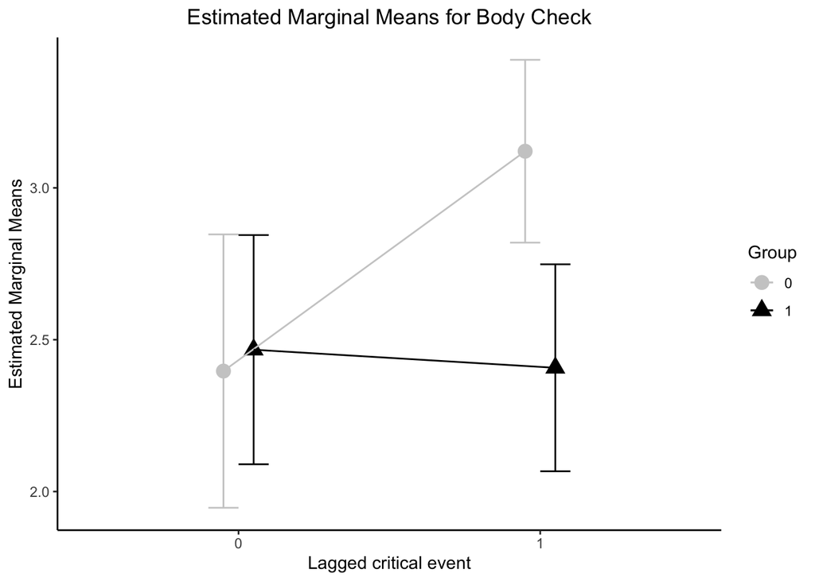

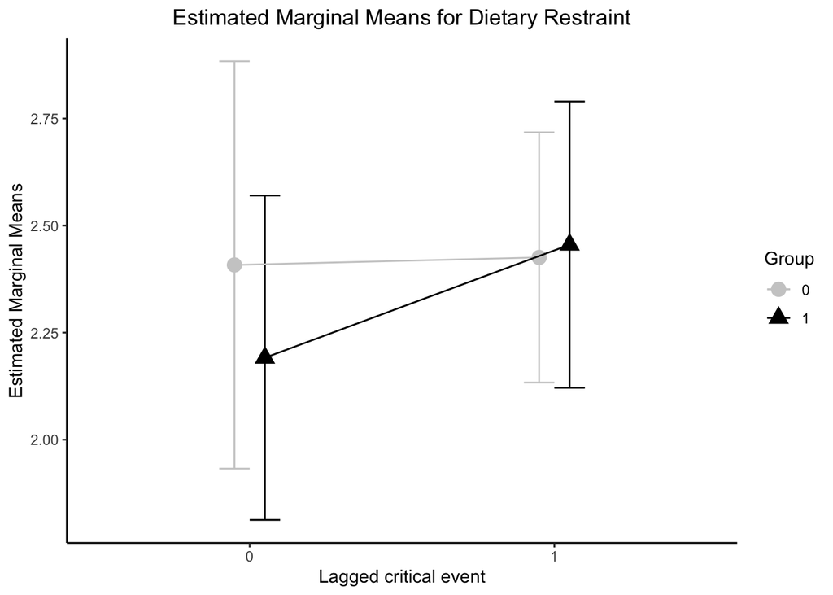

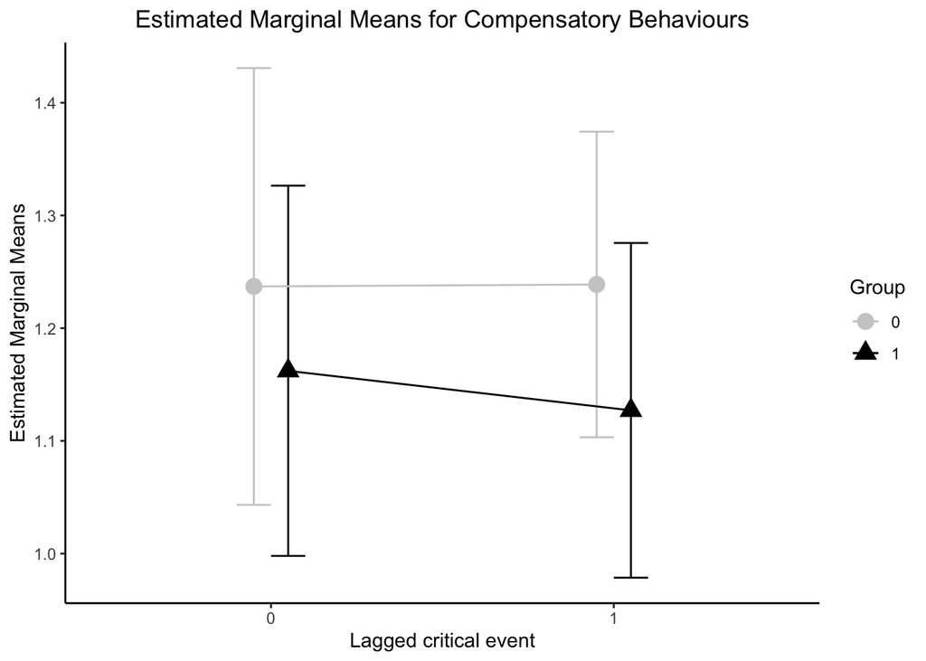

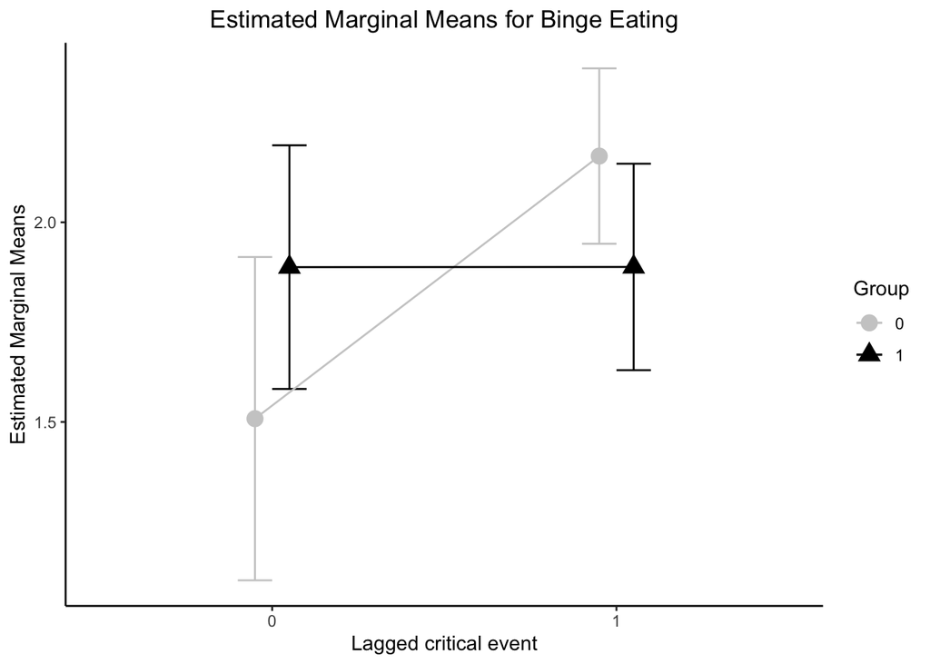

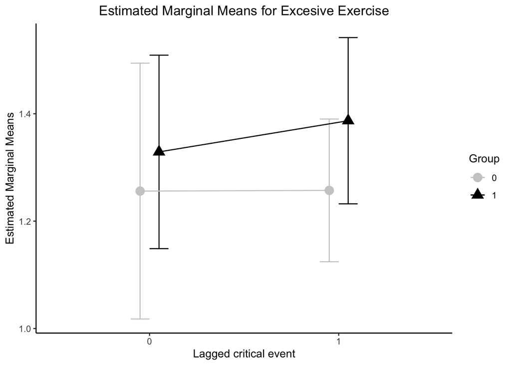

```r
plot_emms <- function(emms_df, x_var_name, group_var_name, plot_title, other_event_label) {
  emms_df[[group_var_name]] <- as.factor(emms_df[[group_var_name]])
  emms_df[[x_var_name]] <- as.factor(emms_df[[x_var_name]])

  p <- ggplot(emms_df, aes(x = !!sym(x_var_name), y = emmean, color = !!sym(group_var_name), shape = !!sym(group_var_name))) +
    geom_point(size = 4, position = position_dodge(width = 0.2)) +
    geom_errorbar(
      aes(ymin = lower.CL, ymax = upper.CL),
      width = 0.2, position = position_dodge(width = 0.2)
    ) +
    geom_line(aes(group = !!sym(group_var_name)), position = position_dodge(width = 0.2)) +
    labs(x = other_event_label, y = "Estimated Marginal Means", title = plot_title, color = "Group", shape = "Group") +
    scale_color_manual(values = c("gray80", "black"), labels = levels(emms_df[[group_var_name]])) +
    scale_shape_manual(values = c(16, 17), labels = levels(emms_df[[group_var_name]])) +  # Circle and triangle
    scale_x_discrete(labels = levels(as.factor(emms_df[[x_var_name]]))) +
    theme_classic() +
    theme(
      legend.position = "right",
      plot.title = element_text(
        hjust = 0.5,
        color = "black"
      )
    )

  return(p)
}


save_emms_plots <- function(emms_results_list, group_variable_name, other_variable_name, dependent_variables_names, other_event_label) {

  for (model_index in seq_along(emms_results_list)) {
    emms_object <- emms_results_list[[model_index]]
    dep_var_name <- names(emms_results_list)[model_index]
    dep_var_for_title <- dependent_variables_names[model_index]

    emms_df <- as.data.frame(emms_object)

    if (!is.null(emms_df)) {
      x_var_name <- other_variable_name
      group_var_name <- group_variable_name

      plot_title <- paste("Estimated Marginal Means for", dep_var_for_title)
      plot <- plot_emms(emms_df, x_var_name, group_var_name, plot_title, other_event_label)
      file_name <- file.path(paste0(dep_var_name, "_plot",".png"))
      ggsave(file_name, plot)
      print(plot)
    }
  }
}


SS_col_for_plots<-c('Self Efficacy')

save_emms_plots(emms_interaction_results, group_variable_name, lagged_critical_event_variable_name, cols_for_plots, 'Lagged critical event')
```

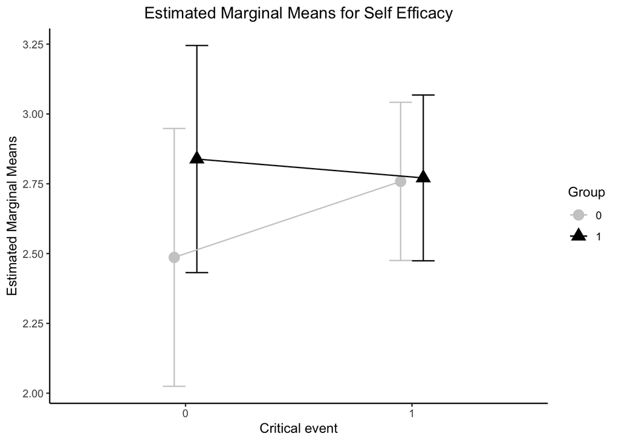

```r
save_emms_plots(emms_interaction_results_SS, group_variable_name, critical_event_variable_name, SS_col_for_plots, 'Critical event')
```

## Secondary analysis on the critical events

### Computing the model for critical event treated as a binomial variable

```r
binomial_analysis <- function(dataset, cols_to_analyze, id_variable_name, day_variable_name, beep_time_variable_name, group_variable_name,
                              control_params, estimation, factors = FALSE) {

  df <- dataset

  if (factors) {
    df[[group_variable_name]] <- as.factor(df[[group_variable_name]])
    df[[day_variable_name]] <- as.factor(df[[day_variable_name]])
  }

  models_results <- list()

  for (variable in cols_to_analyze) {

    formula_binomial <- as.formula(
      paste0(variable, " ~ ", day_variable_name, " + ", beep_time_variable_name, " + ", group_variable_name,
             " + ", day_variable_name, " * ", group_variable_name,
             " + (1 | ", id_variable_name, ")")
    )

    model_output <- glmer(formula_binomial,
                            family = binomial(link = estimation),
                            data = df,
                            control = control_params,
                            na.action = na.omit)
    models_results[[variable]] <- model_output
  }

  return(models_results)
}


estimation_binomial <- "logit"
control_params_binomial <- glmerControl(optimizer = "bobyqa", optCtrl = list(maxfun = 10000000), calc.derivs = TRUE)
cols_for_binomial <- c("critical_event")
factors_binomial <-FALSE


binomial_models_results <- binomial_analysis(data, cols_for_binomial, id_variable_name, day_variable_name,
                                             beep_time_variable_name, group_variable_name,
                                             control_params_binomial, estimation_binomial, factors_binomial)
```

```r
compute_ci_odds_ratios <- function(models, dependent_variables_list) {
  confidence_intervals_list<-list()

  for (variable in dependent_variables_list){
    model<-models[[variable]]
    fixed_effects <- fixef(model)
    ci_log_odds <- confint(model, method='Wald')
    effects_names <- names(fixed_effects)
    ci_log_odds <- ci_log_odds[effects_names, , drop = FALSE]

    odds_ratios <- exp(fixed_effects)
    ci_odds_ratios <- exp(ci_log_odds)

    confidence_intervals<-data.frame(
      Effect = names(fixed_effects),
      Odds_Ratio = odds_ratios,
      Lower_CI = ci_odds_ratios[, 1],
      Upper_CI = ci_odds_ratios[, 2],
      row.names = NULL
    )
    confidence_intervals_list[[variable]]<-confidence_intervals
  }
  return(confidence_intervals_list)
}

odds_ratios_results <- compute_ci_odds_ratios(binomial_models_results, cols_for_binomial)
```

```r
#Results are accessible directly trough the summary
print(summary(binomial_models_results[["critical_event"]]))
```

```
## Generalized linear mixed model fit by maximum likelihood (Laplace Approximation) ['glmerMod']
##  Family: binomial  ( logit )
## Formula: critical_event ~ day + beeptime + group + day * group + (1 |      id)
##    Data: df
## Control: control_params
##
##      AIC      BIC   logLik deviance df.resid
##    918.7    950.7   -453.4    906.7     1528
##
## Scaled residuals:
##     Min      1Q  Median      3Q     Max
## -5.5809  0.0443  0.0654  0.2533  3.5087
##
## Random effects:
##  Groups Name        Variance Std.Dev.
##  id     (Intercept) 13.05    3.612
## Number of obs: 1534, groups:  id, 93
##
## Fixed effects:
##             Estimate Std. Error z value Pr(>|z|)
## (Intercept)  4.16670    0.92234   4.518 6.26e-06 ***
## day          0.12465    0.08111   1.537 0.124319
## beeptime     0.01648    0.02246   0.734 0.462992
## group       -0.96356    0.91766  -1.050 0.293710
## day:group   -0.36920    0.10502  -3.516 0.000439 ***
## ---
## Signif. codes:  0 '***' 0.001 '**' 0.01 '*' 0.05 '.' 0.1 ' ' 1
##
## Correlation of Fixed Effects:
##           (Intr) day    beeptm group
## day       -0.187
## beeptime  -0.365  0.035
## group     -0.557  0.186  0.002
## day:group  0.133 -0.772 -0.020 -0.244
```

```r
print(odds_ratios_results)
```

```
## $critical_event
##        Effect Odds_Ratio    Lower_CI    Upper_CI
## 1 (Intercept) 64.5019846 10.57982010 393.2492217
## 2         day  1.1327548  0.96626827   1.3279266
## 3    beeptime  1.0166208  0.97283875   1.0623732
## 4       group  0.3815337  0.06315715   2.3048537
## 5   day:group  0.6912888  0.56269103   0.8492765
```

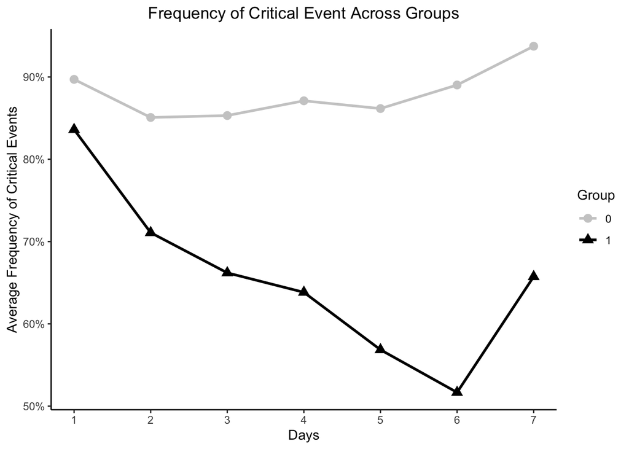

```r
avg_by_day_id <- data %>%
  group_by(across(all_of(c(id_variable_name, day_variable_name)))) %>%
  summarise(
    daily_avg = mean(!!sym(critical_event_variable_name), na.rm = TRUE),
    .groups = "drop"
  )

freq_df <- avg_by_day_id %>%
  left_join(data %>% select(all_of(c(id_variable_name, group_variable_name))) %>% distinct(), by = id_variable_name) %>%
  group_by(across(all_of(c(day_variable_name, group_variable_name)))) %>%
  summarise(
    group_daily_avg = mean(daily_avg, na.rm = TRUE),
    .groups = "drop"
  )



plot_frequencies <- function(dataset, other_time_variable, group_variable_name, time_label) {
  df<-dataset
  df[[group_variable_name]] <- as.factor(df[[group_variable_name]])
  df[[other_time_variable]] <- df[[other_time_variable]] + 1

  ggplot(df, aes(
    x = .data[[other_time_variable]],
    y = group_daily_avg,
    color = .data[[group_variable_name]],
    shape = .data[[group_variable_name]],
    group = .data[[group_variable_name]]
  )) +
    geom_line(linewidth = 1) +
    geom_point(size = 3) +
    scale_y_continuous(labels = scales::percent_format()) +
    scale_color_manual(values = c("gray80", "black")) +
    scale_shape_manual(values = c(16, 17)) +
    labs(
      x = time_label,
      y = "Average Frequency of Critical Events",
      title = "Frequency of Critical Event Across Groups",
      color = "Group",
      shape = "Group"
    ) +
    theme_classic() +
    scale_x_continuous(breaks = unique(df[[other_time_variable]])) +
    theme(
      legend.position = "right",
      plot.title = element_text(
        hjust = 0.5,
        color = "black"
      )
    )
}


frequnecy_plot <- plot_frequencies(freq_df, "day", "group", "Days")
print(frequnecy_plot)
```

```r
file_name_frequnecy_plot <- file.path('Critical_event_frequency_plot.png')
ggsave(file_name_frequnecy_plot, frequnecy_plot)
```

## Save data to a new file at the end

```r
write.csv(data, file='Processed_data.csv', row.names=F)
```